# Random Number Generation

## Random Number Generation

- Uniform Random Number Generation
- Non Uniform Random Number Generation
  - Probability Integral Transform
  - General Transformations
  - Discrete Random variables
  - Accept-reject methods

## Accept-reject methods

- There are many distributions where
  - transform methods or
  - inverse CDF technique fails
- For these cases, we need indirect methods
  - We generate a candidate random variable
  - Only accept it subject to passing a test
- This class of methods is extremely powerful.
  - It will allow us to simulate from virtually any distribution.

## The Fundamental Theorem of Simulation:

Simulating $X \sim f(x)$ is equivalent to simulating $(X,U)\sim Unif((x,u):0 < u < f(x))$.

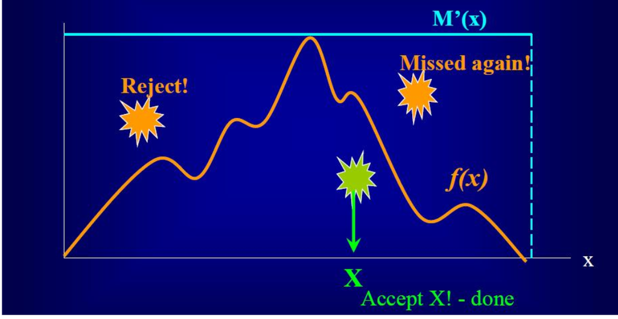

## Accept–Reject Methods

- Only require the functional form of the density $f$ of interest
- Choose $g$ such that it is simpler to simulate random variables from $g$
- **Terminology:** $f$ = target density, $g$ =candidate or instrumental density
- The only constraints we impose on this candidate density $g$
  - $f$ and $g$ have compatible supports (i.e., $g(x) > 0$ when $f(x) > 0$ ).
  - There is a constant $M$ with $\frac{f(x)}{g(x)} \leq M$ for all $x$
  - **Ideally**, the function $g(x)$ is “close” to $f(x)$, ie $M$ is as close to 1 as possible

## Accept-reject algorithm

$X \sim f$ can be simulated as follows.

1. Generate $Y \sim g$ and, independently, generate $U \sim U[0,1]$
2. If $U \leq \frac{f(Y)}{M g(Y)}$, set $X=Y$ —> “Accept Y”
3. If the inequality is not satisﬁed, we then discard $Y$ and $U$ and start again —> “Reject Y”

Note that

- $M = sup_x \frac{f(x)}{g(x)}$
- $Prob(Accept) = \frac{1}{M}$, Expected waiting time for accept is $M$.

## In short - Accept-Reject Algorithm

1. Generate $Y \sim g, U \sim U[0,1]$
2. Accept $~X = Y~$ if $~U \leq \frac{f(Y)}{M g(Y)}$
3. Return to 1 otherwise.

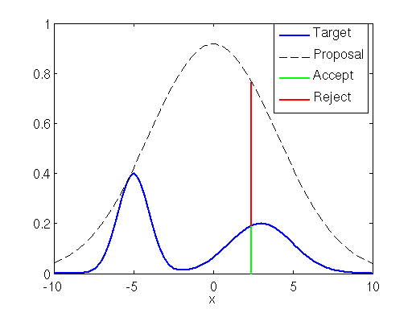

## Algorithm and R Code

1. Generate $Y \sim g, U \sim U[0,1]$
2. Accept $~X = Y~$ if $~U \leq \frac{f(Y)}{M g(Y)}$
3. Return to 1 otherwise.

R code for a single generation $y$ from $f$ would look like:

- Write a function `randg` that generates from $g$ or use a built-in one

```
u=runif(1)*M
y=randg(1)
while ( u>f(y)/g(y) ) # reject, generate new u, y.
  {
  u=runif(1)*M
  y=randg(1)
  }
```

## Several things to note

- Since $f$ and $g$ represent rvs, so does the ratio $\frac{f(Y)}{M g(Y)}$
- The above ratio is independent of the $U$ generated in Step 1.
- Since $sup_x \frac{f(x)}{g(x)} \leq M$ we have $0 < \frac{f(Y)}{M g(Y)} < 1$
- The number of times $N$ that steps 1 and 2 need to be called (i.e, the number of iterations needed to successfully generate X) is itself a rv and has a geometric distribution with “success” probability
  $$p= \displaystyle P(U \leq \frac{f(Y)}{M g(Y)})$$
- So, $P(N=n)= (1-p)^{n-1}p$, $n \geq 1$ and $E[N]= \frac{1}{p}$
- Thus on average the number of iterations required is given by $E[N] = \frac{1}{p}$
- $p = P(Accept) = \frac{1}{M}$ since
  - $p = \displaystyle P(U \leq \frac{f(Y)}{M g(Y)})$
  - Conditioning on $Y=y$, $P(U \leq \frac{f(Y)}{M g(Y)}~| Y=y) = \frac{f(y)}{M g(y)}$
  - Unconditioning and Since $Y$ has density $g(y)$, integrating wrt $y$
    $$p = \int_{-\infty}^{\infty}\frac{f(y)}{M g(y)} g(y) dy = \frac{1}{M}$$
- $E(N) = M$, the bounding constant.
- For fastest termination of algorithm(least number of iterations to generate from $X\sim f$), choose smallest possible $M= sup_x \frac{f(x)}{g(x)}$.

## Accept–Reject Algorithm Example 1:

**Normals from Double Exponentials:**

- **Target density:** $~X \sim f(x) = \frac{1}{\sqrt{2\pi}}e^{\frac{-x^{2}}{2}}$
- **Candidate/instrumental density** $~Y \sim g(y) = \frac{1}{2}e^{-|y|}$

$$\frac{f(y)}{g(y)} = \frac{\frac{1}{\sqrt{2\pi}}e^{\frac{-y^{2}}{2}}}{\frac{1}{2}e^{-|y|}}
\leq \frac{2}{\sqrt{2\pi}}e^\frac{1}{2} \approx 1.3154$$
- $\frac{f(y)}{g(y)}$ has maximum at $y=1$

- Accept $Y$ if $U ≤ \frac{\frac{1}{\sqrt{2\pi}}e^{\frac{-y^{2}}{2}}}{\frac{2}{\sqrt{2\pi}}e^\frac{1}{2}\frac{1}{2}e^{-|y|}} = e^{(−.5Y^2 +|Y|−.5)}$

## Normal and Double Exponential

```r
library(smoothmest)  # package for ddoublex
```

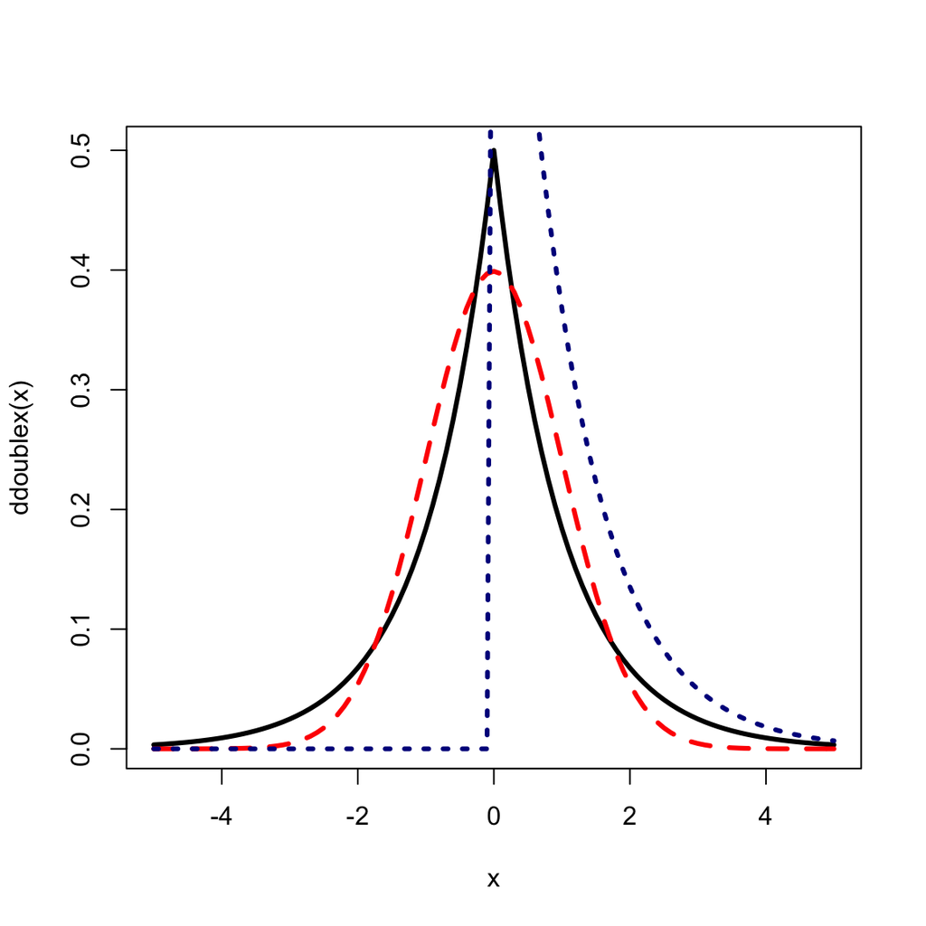

```r
curve(ddoublex, lwd=3, xlim=c(-5,5))
curve(dnorm, lty=2, lwd=3, col="red",add=TRUE)
curve(dexp, lty=3, lwd=3, col="dark blue",add=TRUE)
```

## Rcode: Normals from Double Exponentials

```
## [1] 0.7607
```

```
## [1] 0.760225
```

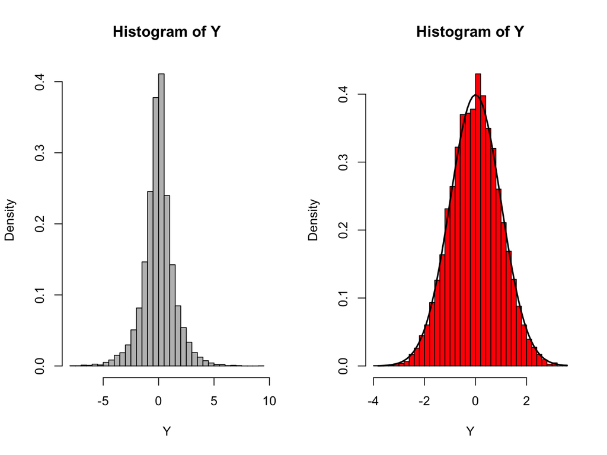

```r
par(mfrow=c(1,2))
nsim=10000
Y=rexp(nsim)
# double exp
for(i in 1:nsim)  if(runif(1)<.5)  Y[i]=-Y[i] #random sign

hist(Y,freq=F,col="gray",breaks=50)#Histogram with 5 breakpoints
#R knows how to multiply by logicals, returns Y[i] or 0.
for(i in 1:nsim) Y[i]=Y[i]*(runif(1)<exp(-.5*Y[i]^2+abs(Y[i])-.5))
Y<-Y[Y!=0]#eliminate zeros
length(Y)/nsim#percent accepted
print(1/1.3154)#1/M
hist(Y,freq=F,col="red",breaks=50)
yplot=seq(min(Y),max(Y),.1)
lines(yplot, dnorm(yplot), lwd=2)
```

## Theory: Accept-Reject Algorithm

- Why does this method work?
- Target is $X, f$ and instrumental is $Y,g$,the conditional pdf of $Y$ when accepted
  $$P(Y = x | Accept ) = P(Y =x ~ |~ U \leq \frac{f(Y )}{Mg(Y )}) = P(X = x) = f(x)$$
  - Using definition of conditional probability and $p = P(U \leq \frac{f(Y )}{Mg(Y )})=\frac{1}{M}$

$$P(Y = x~ |~ U \leq \frac{f(Y )}{Mg(Y )}) = \frac{P(Y = x~ ,~ U \leq \frac{f(Y )}{Mg(Y )})}{P(U \leq \frac{f(Y )}{Mg(Y )})} =M. P(Y = x~ , ~ U \leq \frac{f(Y )}{Mg(Y )})$$
$$= M P(Y = x) P( U \leq \frac{f(x )}{Mg(x )})= Mg(x)P(U \leq \frac{f(x )}{Mg(x )}) = Mg(x)\frac{f(x )}{Mg(x )}=f(x)$$

- Simulating from $g$, the output of this algorithm is exactly distributed from $f$

## Further notes about AR algorithm

- The Accept–Reject method is applicable in any dimension
- As long as $g$ is a density over the same space as $f$
- $$P(accept | Y ) = P( U\leq \frac{f(Y)}{Mg(Y)} | Y ) = f(Y)/Mg(Y)$$
- $$P(accept) = \sum_y P(accept | y )g(y) = 1/M$$
- Only need to know $f/g$ up to a constant, don’t need constants in the density
- Only need an upper bound on $M$
- Ignoring normalizing constants in density gives an upper bound $M_1$ on $M= sup_x \frac{f(x)}{g(x)}$ calculated with density.
- So, if constants are ignored and you get an upper bound $M_1$, $P(acceptance)$ is no longer $\frac{1}{M_1}$
- Rule of Thumb: $g$ should have thicker tails than $f$
- Pay attention to acceptance rate when you don’t use constants in accept-reject decision criterion.

## Accept–Reject Algorithm Example 2:

**Beta from Uniform:**

- To Generate $X \sim beta(3,3)$.
- **Use a uniform candidate**
  - Has heavier tails than Beta(3,3). Is this a good candidate?

## Plot it

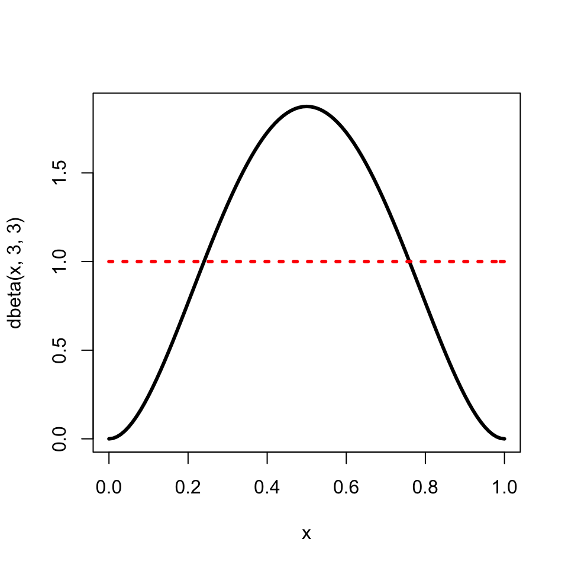

## Theory:

- Target density has PDF
  $$f(x)\propto x^{2}(1-x)^{2}.$$
- Candidate $g(x)=1$ (uniform)
- Compute $M$
  $$max_{0 < x < 1}x^{2}(1-x)^{2}=0.5^{4}=0.0625$$
- Accept $Y$ if $U \leq \frac{x^{2}(1-x)^{2}}{0.0625}$

```
## [1] 0.527
```

```
## [1] 16
```

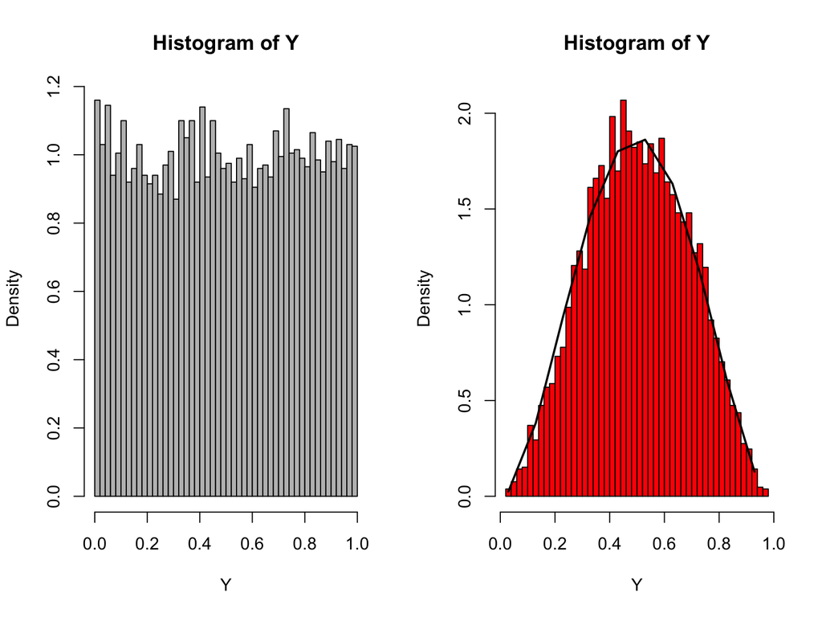

```r
par(mfrow=c(1,2))
nsim=10000
Y=runif(nsim)
hist(Y,freq=F,col="gray",breaks=50)
for(i in 1:nsim) Y[i]=Y[i]*(runif(1)<(Y[i]^2*(1-Y[i])^2/.0625))
Y<-Y[Y!=0]                  #eliminate zeros
length(Y)/nsim              #percent accepted
1/0.0625 # not 1/M
hist(Y,freq=F,col="red",breaks=50)
yplot=seq(min(Y),max(Y),.1)
lines(yplot, dbeta(yplot,3,3), lwd=2)
```

- Only accept 50%(low), $f$ is far from $g$, $M=0.0625$ not close to 1.
- Used $M$ upto a multiplicative constant, so $P(accept) \neq \frac{1}{M}$
- need more iterations for better fit.

## With 50K and 500K iterations

```r
par(mfrow=c(1,4))
nsim=50000
Y=runif(nsim)
hist(Y,freq=F,col="gray",breaks=50)
for(i in 1:nsim) Y[i]=Y[i]*(runif(1)<((Y[i]^2*(1-Y[i])^2)/0.0625))
Y<-Y[Y!=0]                  #eliminate zeros
cat('Percent accepted =',length(Y)/nsim, 'is similar, but fit is better')       #percent accepted
hist(Y,freq=F,col="red",breaks=50)
yplot=seq(min(Y),max(Y),.1)
lines(yplot, dbeta(yplot,3,3), lwd=2)
nsim=500000
Y=runif(nsim)
hist(Y,freq=F,col="gray",breaks=50)
for(i in 1:nsim) Y[i]=Y[i]*(runif(1)<((Y[i]^2*(1-Y[i])^2)/0.0625))
Y<-Y[Y!=0]                  #eliminate zeros
cat('Percent accepted =',length(Y)/nsim, 'is similar, and  fit is even better')     #percent accepted
hist(Y,freq=F,col="red",breaks=50)
yplot=seq(min(Y),max(Y),.1)
lines(yplot, dbeta(yplot,3,3), lwd=2)
```

## Output for 50K and 500K iterations

```
## Percent accepted = 0.53172 is similar, but fit is better
```

```
## Percent accepted = 0.532612 is similar, and  fit is even better
```

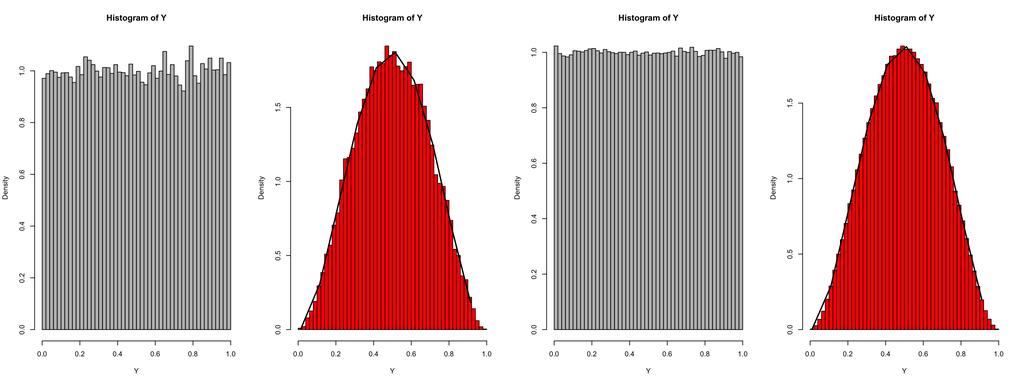

## Simulating Normals from Cauchy

What do the pdf’s look like?

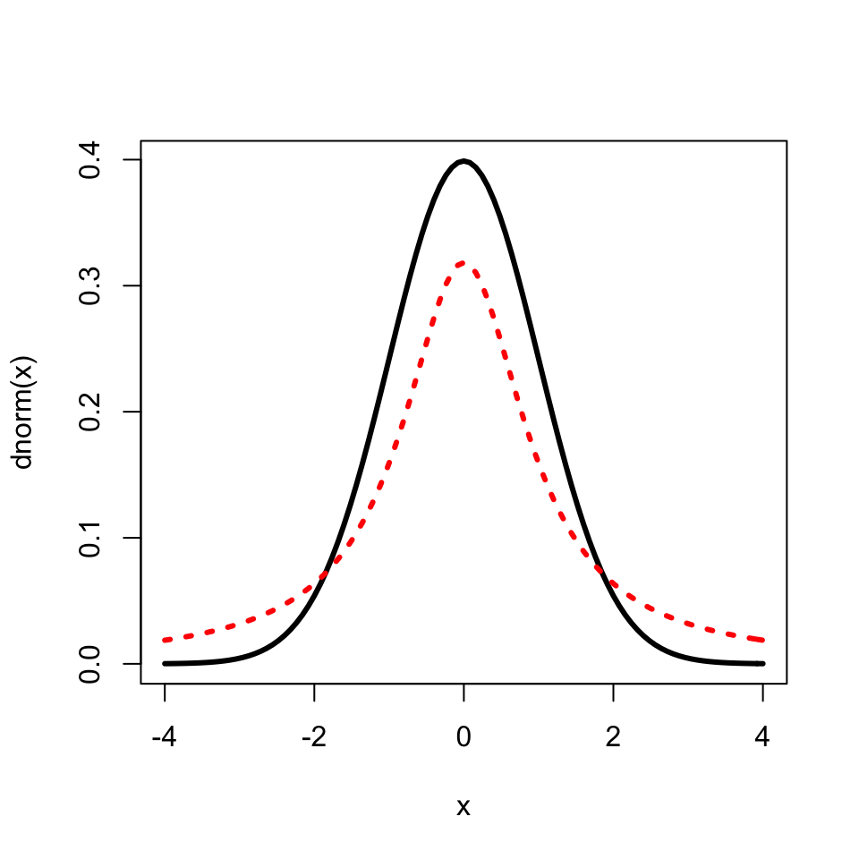

## Simulating Normals from Cauchy

Why do this?

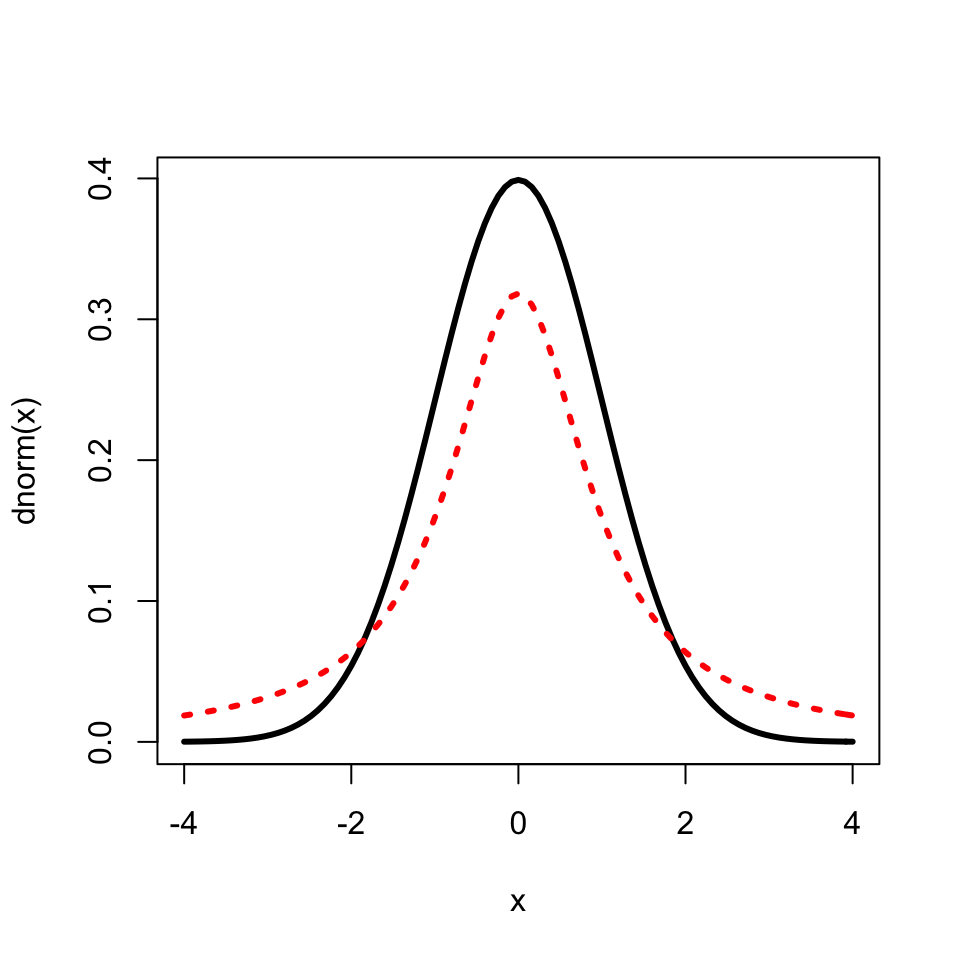

```
- Cauchy has heavier tails than normal - makes a good instrumental density
- simulate cauchy by inverse CDF - easy
```

## Simulating Normals using Cauchy random variables.

Here our **target density** is the standard Normal distribution with PDF

$$f(x) = \frac{1}{\sqrt{2\pi}} e^{-x^{2}/2}$$

**Candidate/Instrumental density:** Cauchy(0,1) random variable has PDF

$$g(x)=\frac{1}{\pi}\,\frac{1}{1+x^{2}},\quad -\infty < x < \infty$$

- Cauchy CDF
  $$F(x) =\mathbb{P}(X\leq x) =\int_{-\infty}^{x}\frac{1}{\pi}\,\frac{1}{1+t^{2}} dt$$
  $$=\left.\frac{1}{\pi}\tan^{-1}(t)\right|_{t=-\infty}^{x}=\frac{1}{\pi}\left(\tan^{-1}x+\frac{\pi}{2}\right).$$
- It is now easy to calculate the inverse transformation to simulate:
  $$\pi y =\tan^{-1}x+\pi/2$$
  $$\pi(y-1/2) =\tan^{-1}x$$
  $$\tan(\pi(y-1/2)) =x=F^{-1}(y)$$

and it’s inverse CDF is

$$F^{-1}(y) = x = \tan(\pi(y-1/2))$$
So it is EASY to simulate from a Cauchy via inverse CDF.

## Simulating Normals using Cauchy random variables.

Cauchy has heavier tails than normal - makes a good instrumental density.

Finding the M such that Normal < M. Cauchy
$$\frac{1}{\sqrt{2\pi}} e^{-x^{2}/2} \leq M\,\frac{1}{\pi(1+x^{2})},\quad\mbox{or}$$
$\sqrt{\frac{\pi}{2}}(1+x^{2}) e^{-x^{2}/2} \leq M$

## Simulating Normals using Cauchy random variables.

**Algorithm:**

- Generate $U \sim Unif(0,1)$ and $Y \sim Cauchy(0,1)$;
- Accept $X = Y$ if $U < f(Y)/Mg(Y)$;
- Return to 1. otherwise.

and via actual simulation

```
## [1] 0.6594131
```

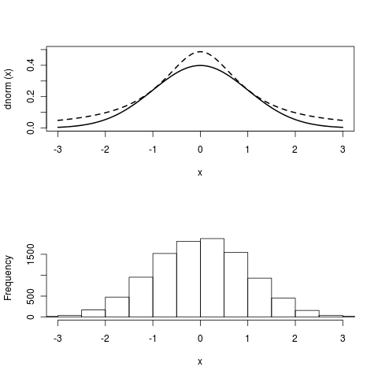

Plot of the target/proposal densities, plus histogram

## Code

```r
#Simulating Normal with a Cauchy
#We cover the standard Normal density with a Cauchy proposal density
# and use the accept-reject algorithm.
# randnorm function
# randnorm.R

randnorm <- function(n){
  M <- 1.5203 # bound used in A/R algo
  i <- 0; N <- 0 # init and storage
  z <- rep(0, times = n)
  while(i < n){ # keep going until n accepts
      x <- tan(pi*(runif(1) - 0.5))  # simulate a Cauchy
      u <- runif(1)                  # simulate a Uniform
      f <- 1/sqrt(2*pi)*exp(-x^2/2)  # compute f(x)
      g <- 1/pi/(1+x^2)  # compute g(x)

      if (u <= f/M/g){ # got another accept
        i <- i + 1
        z[i] <- x # save this one
      }

      N <- N + 1 # keep track of num trials
    }
list(z = z, accept = n/N) # variates and percent accepted
}


tmp <- randnorm(10000)
tmp$accept
```

## Exercise

1. Plot the candidate density and histogram, the simulated normal density and the true normal density.
2. Observe what happens to acceptance rate, fit as $n$ increases

## Exercise

```r
par(mfrow=c(1,4))
tmp <- rand_norm(1000)
cat('Percent accepted =',tmp$accept)        #percent accepted
hist(tmp$z,freq=F,col="red",breaks=50)
x=seq(-4,4,.1)
curve(dnorm(x), xlim=c(-4,4),lty=1,lwd=3, add=TRUE)
```

## A wierd distribution code

- True distribution is a wierd trig function
- Can use normal as instrumental.

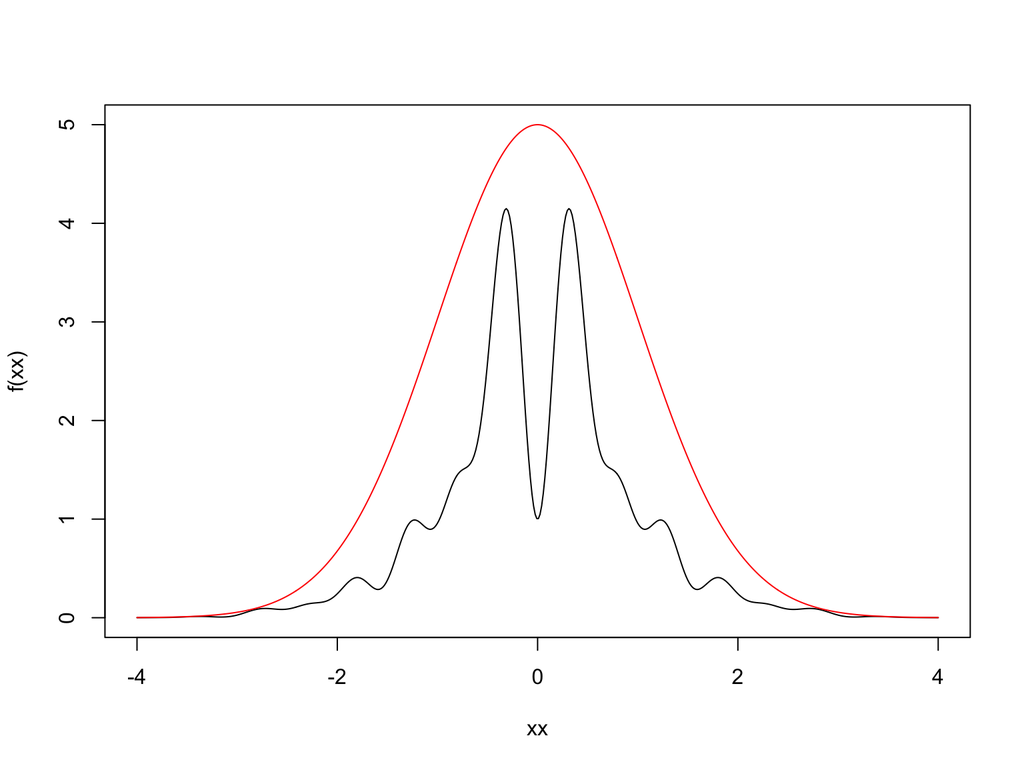

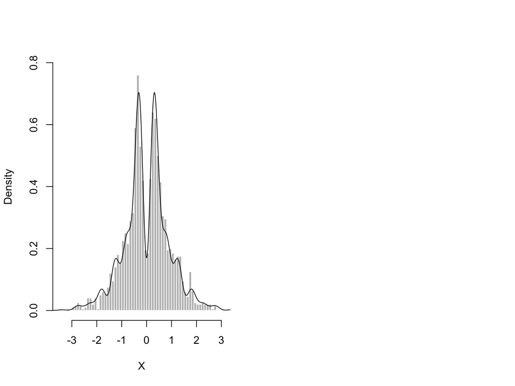

## A wierd distribution code

```r
f <- function(x) exp(-x**2 / 2) * (sin(6 * x)**2 + 3 * cos(x)**2 * sin(4 * x)**2 + 1)
g <- function(x) 5 * exp(-x**2 / 2)
xx <- seq(-4, 4, len=500)
plot(xx, f(xx), type="l", ylim=c(0, 5))
lines(xx, g(xx), col=2)
n <- 2000
X <- c()
i <- 0
repeat {

  Z <- rnorm(1)
  U <- runif(1)
  if(U <= f(Z) / g(Z)) {

    X <- c(X, Z)
    i <- i + 1

  }
  if(i >= n) break

}
par(mfrow=c(1,2))
hist(X, freq=FALSE, ylim=c(0, 0.8), breaks=50, col="gray", border="white", main="")
norm <- integrate(f, -4, 4)$value
ff <- function(x) f(x) / norm
lines(xx, ff(xx))
```

## Simulating from Discrete distributions.

We want to simulate from a discrete RV $X$ that takes values $1,2,...,10$ with probabilities

$$p = (.11, .12, .09, .08, .12, .10, .09, .09, .10, .10)$$

These are the target $p_{j}$’s.

Choose candidate density Y: $Y\sim DiscUnif(1,2,\ldots,10)$ with $q_{j}=0.1$, $j=1,\ldots,10$.

Next, we need to find

$$M=\max_{j}\frac{p_{j}}{q_{j}}=\frac{0.12}{0.10}=1.2.$$

## AR Algorithm:

1. Generate $Y \sim DiscUnif(1,10)$ and $U\sim Unif(0,1)$;
2. Accept $X = Y$ if $U < p_{Y}/1.2 q_{Y}$;
3. Return to 1 otherwise.

## Exercise

Generating one observation from the above discrete uniform

```r
mydiscrete1 <- function(){
  accept <- FALSE
  p <- c(.11, .12, .09, .08, .12, .10, .09, .09, .10, .10)
  while (!accept){
    y <- sample(10, size = 1);
    u <- runif(1)
    accept <- (u < p[y]/(1.2*0.1));
  }
  return(y)
}

y <- mydiscrete1()
y
```

```
## [1] 6
```

## Simulate a whole vector of discrete RVs, all IID with density p

Generalize our function to include arguments $\mathbf{p}$ and $n$, the desired length of simulation.

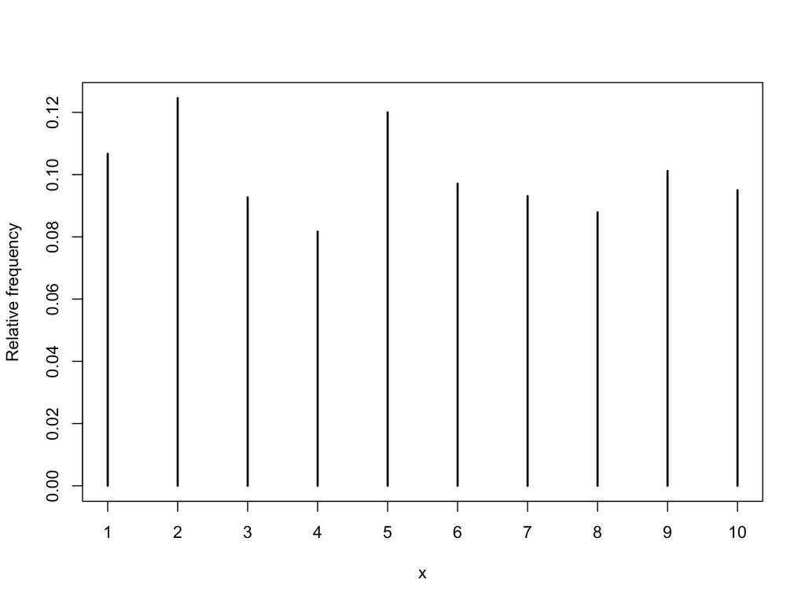

```r
#This function generates a discrete distribution via the accept-reject algorithm.
mydiscreteN <- function(p,N){
  # p is the desired target density on 1,...,k.
  # N is the number of observations desired
  x <- rep(0, times = N)# initialize
  k <- length(p)        # the support of p
  M <- k*max(p)   # the bound size
  for(i in seq.int(N)){
    accept <- FALSE   # initialize
    while (!accept){  # continue until we accept
      y <- sample(k, size = 1)  # y is disc unif 1...k
      u <- runif(1)         # u is unif(0,1)
      accept <- ( u < p[y]/(M*1/k) )# is TRUE if A/R condition satisfied
    }
    x[i] <- y # this y is a good one
  }
  return(x)
}

p <- c(.11, .12, .09, .08, .12, .10, .09, .09, .10, .10)
x <- mydiscreteN(p, 10000)
y<-table(x) #a contingency table of the counts at each combination of factor levels.
z<-prop.table(x)
plot(prop.table(table(x)), ylab = "Relative frequency")
```

## Accept–Reject Algorithm Lab

**Simulating Beta(2.5, 4.5) Random Variables: Which method is better?**

- Earlier, AR with uniform candidate or via transform of Gamma rv, we could simulate Beta(a,b) only for iteger parameters.
- AR can simulate all Beta distributions, even non-integral

We wish to simulate Beta(2.5,4.5) random variables with target density
$$f(x) \propto x^{1.5}(1-x)^{3.5}.$$

To do this we will use the Accept/Reject Algorithm with two different instrumental densities.

- **Method I:** Use uniform RV’s with instrumental density
  $$g_{1}(x) = 1,\quad 0 < x < 1.$$
- you may use $M \approx 0.0472$.
- to simulate from $g_{1}$ use the command `x <- runif(1)`.
- **Method II:** Use the average of two uniform RV’s with instrumental density
  $$g_{2}(x) = 2 - |4x - 2|,\quad 0 < x <1.$$
  -Notes:
- you may use $M \approx 0.0554$.
- the `R` function for absolute value is `abs`.
- to simulate from $g_{2}$ use the command `x <- mean(runif(2))`.

**Question:** Which method is better?

- Write a program that simulates 10,000 Beta(2.5,4.5) random variables using both methods.
- Compare the acceptance rates and decide which one is the better algorithm.
- Graph histograms of your results.